# Evidencia 2 - Parte 2

## Creamos un archivo fasta con todas las secuencias

```r
write.dna(virus_sequences,  file ="virus_seqs.fasta", format = "fasta", append =
FALSE, nbcol = 6, colsep = " ", colw = 10)

virus_seq_not_align <- readDNAStringSet("virus_seqs.fasta", format = "fasta")
virus_seq_not_align
```

```
## DNAStringSet object of length 21:
##      width seq                                              names
##  [1] 29882 ATTAAAGGTTTATACCTTCCCAG...GGAGAATGACAAAAAAAAAAAA MT844047
##  [2] 29409 ATGGAGAGCCTTGTCCCTGGTTT...AGTTAACTTTAATCTCACATAG MT810698
##  [3] 29726 GATCTGTTCTCTAAACGAACTTT...TACAGTGAACAATGCTAGGGAG MW553311
##  [4] 29611 AGATCTGTTCTATAAACGAACTT...AGTAGATGTAGTTAACTTTAAT MW309435
##  [5] 29813 ACTTTCGATCTCTTGTAGATCTG...GCTATCCCCATGTGATTTTAAT MT919768
##  ...   ... ...
## [17] 29903 NNNNNNNNNNTATACCTTCCCAG...NNNNNNNNNNNNNNNNNNNNNN LR991977
## [18] 29779 NNNNNNNNNNNNNNNNNNNNNNN...GTGTAAAATTAATTTTAGTAGT LR883306
## [19] 29834 AACAAACCAACCAACTTTCGATC...ATTTTAATAGCTTCTTAGGAGA MW423684
## [20] 29818 AACAAACCAACCAACTTTCGATC...TTAGTAGTGCTATCCCCATGTG MT459924
## [21] 29806 CTCTTGTAGATCTGTTCTCTAAA...TATCCCCATGTGATTTTAATAG MT973296
```

## Alineamos las secuencias

```r
virus_seq_not_align <- OrientNucleotides(virus_seq_not_align)
```

```
## ========================================================================================================================================================================================================
##
## Time difference of 0.21 secs
```

```r
virus_seq_align <- AlignSeqs(virus_seq_not_align)
```

[output not shown]

## Guardamos el resultado y obtenemos el archivo

```r
writeXStringSet(virus_seq_align, file="virus_seq_align.fasta")
virus_aligned <- read.alignment("virus_seq_align.fasta", format = "fasta")
```

## Creamos una matriz de distancia y la visualizamos

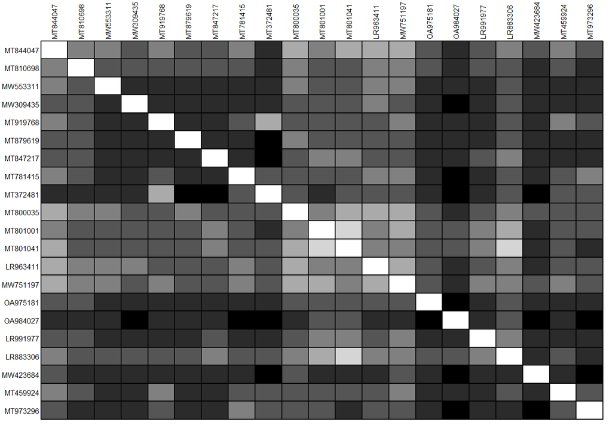

```r
matriz_distancia <- dist.alignment(virus_aligned, matrix = "similarity")
temp <- as.data.frame(as.matrix(matriz_distancia))
table.paint(temp, cleg=0, clabel.row=.5, clabel.col=.5) + scale_color_viridis()
```

## Ahora sí hacemos el arbol

```r
virus_tree <- nj(matriz_distancia)
class(virus_tree)
```

```
## [1] "phylo"
```

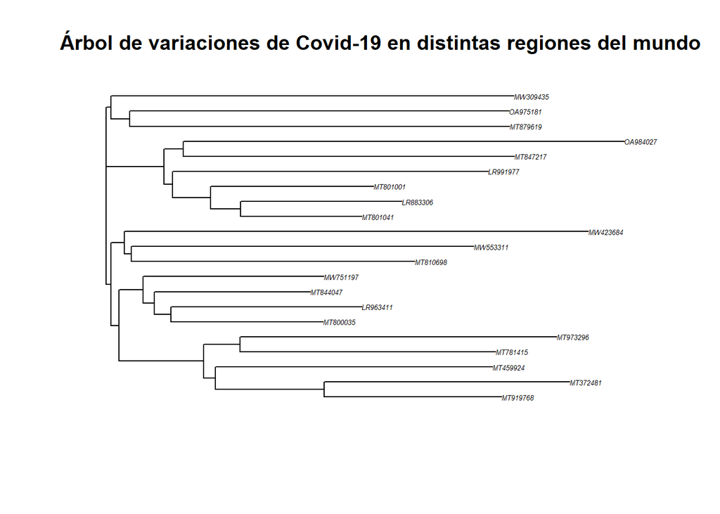

```r
virus_tree <- ladderize(virus_tree)
plot(virus_tree, cex = 0.4)
title("Árbol de variaciones de Covid-19 en distintas regiones del mundo")
```

## Interpretación del árbol

```r
#Aqui la interpretacion del árbol filogenético que se muestra anteriormente
```

A partir del árbol filogenético que se generó anteriormente, se puede suponer que no existe una relación estricta entre las variantes del Covid-19 y las regiones en las que fueron registradas. Más que otra cosa, en el árbol, se observa que se separan las variantes del mismo “tipo”, como los B.1, los cuales se ven en la parte superior (variantes Reino Unido, Pakistán y Canada). En la parte media del árbol hay variaciones más “extrañas” como el AD.2, el L.2 y el B.1.1.219; en dicha rama no se puede observar una relación estricta entre las variantes. Después, en la parte baja del árbol, se dividen muy explícitamente las variantes: primero se encuentran más variantes del “tipo” B.1 (de Italia, Argentina, Kenya, Estados Unidos, etc…), luego en otra rama se encuentran los variantes de A (A.2.2 y A.6 de Australia y Tailandia respectivamente) y finalmente se encuentran otras variantes de B (B.40, B.6.6 y B.6 de Grecia, Malasia y Filipinas respectivamente). Lo mencionado anteriormente indica claramente que el árbol separa las variantes por la relación que tienen y que ella no depende de la región geográfica en la que se registraron; la información sugiere que la relación genética que las variantes tienen depende o está muy relacionado con el “tipo” de variante que es. Finalmente, es importante notar que sí es probable que “tipos” similares de variantes tengan orígenes geográficos similares (originalmente), pero esto no es lo que se está analizando necesariamente en las gráficas generadas en este documento y por ello no es la conclusión principal que se genera.